# Data Science

Srivasan

Thursday, May 11, 2017

## Download R and Rstudio

- https://cran.r-project.org/bin/windows/base/
- https://www.rstudio.com/products/rstudio/download/

## Installing packages

- install.packages(‘ggplot2’)

## Importing Data in R

```
##   Company_Name Dependent.Company.Status year.of.founding
## 1     Company1                  Success          No Info
## 2     Company2                  Success             2011
## 3     Company3                  Success             2011
## 4     Company4                  Success             2009
## 5     Company5                  Success             2010
## 6     Company6                  Success             2010
##   Age.of.company.in.years Internet.Activity.Score
## 1                 No Info                      -1
## 2                       3                     125
## 3                       3                     455
## 4                       5                     -99
## 5                       4                     496
## 6                       4                     106
##     Short.Description.of.company.profile
```

[output cut: 489 more lines]

```
##      Company_Name Dependent.Company.Status year.of.founding
##  Company1  :  1   Failed :167              2010   : 76
##  Company10 :  1   Success:305              2012   : 73
##  Company100:  1                            2011   : 70
##  Company101:  1                            No Info: 59
##  Company102:  1                            2009   : 49
##  Company103:  1                            2007   : 42
##  (Other)   :466                            (Other):103
##  Age.of.company.in.years Internet.Activity.Score
##  4      : 76             Min.   :-725.0
##  2      : 73             1st Qu.:  -3.5
##  3      : 70             Median :  60.0
##  5      : 49             Mean   : 114.2
##         : 44             3rd Qu.: 216.0
##  7      : 42             Max.   :1535.0
##  (Other):118             NA's   :65
##                     Short.Description.of.company.profile
##                                       :149
##  Big Data Analytics                   :  4
##  Acquire and retain valuable customers:  2
##  Media Hosting                        :  2
##  Online wine service                  :  2
##  SaaS Marketing Automation            :  2
##  (Other)                              :311
##                     Industry.of.company Focus.functions.of.company
##                               :124      Operations: 31
##  Analytics                    : 53                : 30
##  Analytics|Marketing          : 16      Marketing : 29
##  E-Commerce                   :  9      analytics : 27
##  Marketing                    :  8      operation : 25
##  Analytics|Enterprise Software:  7      marketing : 21
##  (Other)                      :255      (Other)   :309
##                                                                            Investors
##                                                                                 :140
##  TechStars                                                                      :  7
##  500 Startups|Seedcamp                                                          :  2
##  AxVentures-Pymar Fund|Ax Ventures                                              :  2
##  Evergreen Venture Partners|Sefi Visiger|Yair Goldfinger|Arik Vardi|Eilon Tirosh:  2
##  Khosla Ventures                                                                :  2
##  (Other)                                                                        :317
```

[output cut: 497 more lines]

```
##  0          :379          0          :360       0          :323
##  No Info    : 61          No Info    : 61       No Info    : 61
##  5.882352941:  4          11.11111111:  7       5.555555556: 13
##  2.777777778:  3          2.777777778:  5       2.777777778:  8
##  5          :  3          5.555555556:  5       11.11111111:  6
##  1.851851852:  2          5.882352941:  4       5.882352941:  5
##  (Other)    : 20          (Other)    : 30       (Other)    : 56
##   Renown.score
##  0      : 97
##  No Info: 61
##  1      : 49
##  5      : 46
##  2      : 43
##  4      : 42
##  (Other):134
```

```
## 'data.frame':    472 obs. of  116 variables:
##  $ Company_Name                                                                                                                     : Factor w/ 472 levels "Company1","Company10",..: 1 112 223 334 418 429 440 451 462 2 ...
##  $ Dependent.Company.Status                                                                                                         : Factor w/ 2 levels "Failed","Success": 2 2 2 2 2 2 2 2 2 2 ...
##  $ year.of.founding                                                                                                                 : Factor w/ 16 levels "1997","1999",..: 16 13 13 11 12 12 13 12 13 15 ...
##  $ Age.of.company.in.years                                                                                                          : Factor w/ 17 levels "","1","10","11",..: 17 10 10 12 11 11 10 11 10 2 ...
##  $ Internet.Activity.Score                                                                                                          : int  -1 125 455 -99 496 106 39 139 306 53 ...
##  $ Short.Description.of.company.profile                                                                                             : Factor w/ 314 levels ""," Daa Management Platform",..: 297 1 105 279 276 30 1 1 98 28 ...
##  $ Industry.of.company                                                                                                              : Factor w/ 193 levels "","Advertising",..: 1 129 23 152 40 114 17 72 44 123 ...
##  $ Focus.functions.of.company                                                                                                       : Factor w/ 165 levels "","\\","advertising",..: 95 75 96 71 71 6 112 19 68 112 ...
##  $ Investors                                                                                                                        : Factor w/ 320 levels "",".406 Ventures|fidelity growth partners global|Fidelity Growth Partners Europe",..: 179 1 296 206 83 232 230 223 233 175 ...
##  $ Employee.Count                                                                                                                   : int  3 NA 14 45 39 14 7 29 16 3 ...
##  $ Employees.count.MoM.change                                                                                                       : int  0 NA 0 10 3 8 0 -12 45 NA ...
##  $ Has.the.team.size.grown                                                                                                          : Factor w/ 6 levels "","No","No Info",..: 2 2 2 2 2 2 2 2 2 2 ...
##  $ Est..Founding.Date                                                                                                               : Factor w/ 161 levels "","1/1/1999",..: 1 1 48 122 86 101 13 12 13 107 ...
##  $ Last.Funding.Date                                                                                                                : Factor w/ 285 levels "","1/1/2006",..: 179 1 46 165 81 270 281 77 109 47 ...
```

[output cut: 86 more lines]

- call library for visualizing the data.
- library(ggplot2)

```
##   carat       cut color clarity depth table price    x    y    z
## 1  0.23     Ideal     E     SI2  61.5    55   326 3.95 3.98 2.43
## 2  0.21   Premium     E     SI1  59.8    61   326 3.89 3.84 2.31
## 3  0.23      Good     E     VS1  56.9    65   327 4.05 4.07 2.31
## 4  0.29   Premium     I     VS2  62.4    58   334 4.20 4.23 2.63
## 5  0.31      Good     J     SI2  63.3    58   335 4.34 4.35 2.75
## 6  0.24 Very Good     J    VVS2  62.8    57   336 3.94 3.96 2.48
```

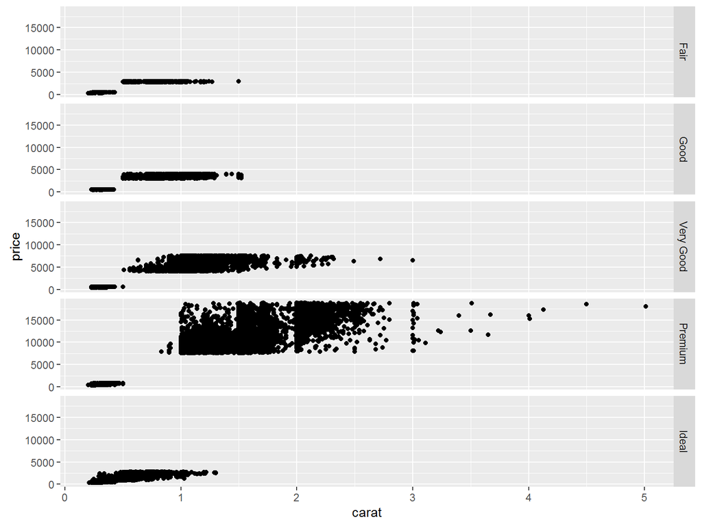

## Cleaning of Data Frame

One of the prominent inconsistency is missing value are represented as “No Info” as well as “blanks”. So, the first step should be to replace “No Info” and “blanks” with “NA” to get better sense of missing values in data.

```
##      Company_Name Dependent.Company.Status year.of.founding
##  Company1  :  1   Failed :167              2010   : 76
##  Company10 :  1   Success:305              2012   : 73
##  Company100:  1                            2011   : 70
##  Company101:  1                            2009   : 49
##  Company102:  1                            2007   : 42
##  Company103:  1                            (Other):103
##  (Other)   :466                            NA's   : 59
##  Age.of.company.in.years Internet.Activity.Score
##  4      : 76             Min.   :-725.0
##  2      : 73             1st Qu.:  -3.5
##  3      : 70             Median :  60.0
##  5      : 49             Mean   : 114.2
##  7      : 42             3rd Qu.: 216.0
##  (Other):103             Max.   :1535.0
##  NA's   : 59             NA's   :65
##                     Short.Description.of.company.profile
##  Big Data Analytics                   :  4
##  Acquire and retain valuable customers:  2
##  Media Hosting                        :  2
##  Online wine service                  :  2
##  SaaS Marketing Automation            :  2
##  (Other)                              :311
##  NA's                                 :149
##                     Industry.of.company Focus.functions.of.company
##  Analytics                    : 53      Operations: 31
##  Analytics|Marketing          : 16      Marketing : 29
##  E-Commerce                   :  9      analytics : 27
##  Marketing                    :  8      operation : 25
##  Analytics|Enterprise Software:  7      marketing : 21
##  (Other)                      :255      (Other)   :309
##  NA's                         :124      NA's      : 30
##                                                                            Investors
##  TechStars                                                                      :  7
##  500 Startups|Seedcamp                                                          :  2
##  AxVentures-Pymar Fund|Ax Ventures                                              :  2
##  Evergreen Venture Partners|Sefi Visiger|Yair Goldfinger|Arik Vardi|Eilon Tirosh:  2
##  Khosla Ventures                                                                :  2
##  (Other)                                                                        :317
##  NA's                                                                           :140
```

[output cut: 497 more lines]

```
##  0          :379          0          :360       0          :323
##  5.882352941:  4          11.11111111:  7       5.555555556: 13
##  2.777777778:  3          2.777777778:  5       2.777777778:  8
##  5          :  3          5.555555556:  5       11.11111111:  6
##  1.851851852:  2          5.882352941:  4       5.882352941:  5
##  (Other)    : 20          (Other)    : 30       (Other)    : 56
##  NA's       : 61          NA's       : 61       NA's       : 61
##   Renown.score
##  0      : 97
##  1      : 49
##  5      : 46
##  2      : 43
##  4      : 42
##  (Other):134
##  NA's   : 61
```

Next step would be to understand amount of missing values in data. Any variable missing more than 50% should not be used in modeling as it can give false impression of relationship with dependent and can pollute the model. Being on conservative side generally we prefer to keep variable with less than 40% missing value only for treatment and anything above 40% missing values are to be used in testing only to give additional insights.

```
##                               variable percent_missing
## 1                         Company_Name             0.0
## 2             Dependent.Company.Status             0.0
## 3                     year.of.founding            12.5
## 4              Age.of.company.in.years            12.5
## 5              Internet.Activity.Score            13.8
## 6 Short.Description.of.company.profile            31.6
```

# keeping only variables with less than 40% missing

```r
new_var<-percent_mis_var$variable[which(percent_mis_var$percent_missing<=40)]
new_Start<-start[new_var]
head(new_Start)
```

```
##   Last.Funding.Date Team.size.all.employees Percent_skill_Investment
## 1         5/26/2013                      15                        0
## 2              <NA>                      20                        0
## 3        10/23/2013                      10                        0
## 4         5/10/2012                      50                        0
## 5        12/11/2013                      40                        0
## 6         9/17/2013                      14                        0
##   Company_Name Prescriptive.analytics.business
## 1     Company1                              No
## 2     Company2                              No
## 3     Company3                              No
## 4     Company4                              No
## 5     Company5                              No
## 6     Company6                              No
##   Survival.through.recession..based.on.existence.of.the.company.through.recession.times
```

[output cut: 468 more lines]

```r
other_data<-percent_mis_var$variable[which(percent_mis_var$percent_missing>40)]
```